# 11.6

AMANDA LIU

2017年11月5日

```r
library(tidyverse)
library(modelr)
options(na.action = na.warn)
```

Exercises 23.3.3 #1, 3 23.4.5 #2(only the part for sim3), 3 3.5.1 (not a typo, it’s back in chapter 3)#2,3,6 For number 6, try switching the example just before the exercise

```r
grid <- sim1 %>% data_grid(x)
grid
```

```
## # A tibble: 10 x 1
##        x
##    <int>
##  1     1
##  2     2
##  3     3
##  4     4
##  5     5
##  6     6
##  7     7
##  8     8
##  9     9
## 10    10
```

23.3.3 #1 Instead of using lm() to fit a straight line, you can use loess() to fit a smooth curve. Repeat the process of model fitting, grid generation, predictions, and visualisation on sim1 using loess() instead of lm(). How does the result compare to geom_smooth()?

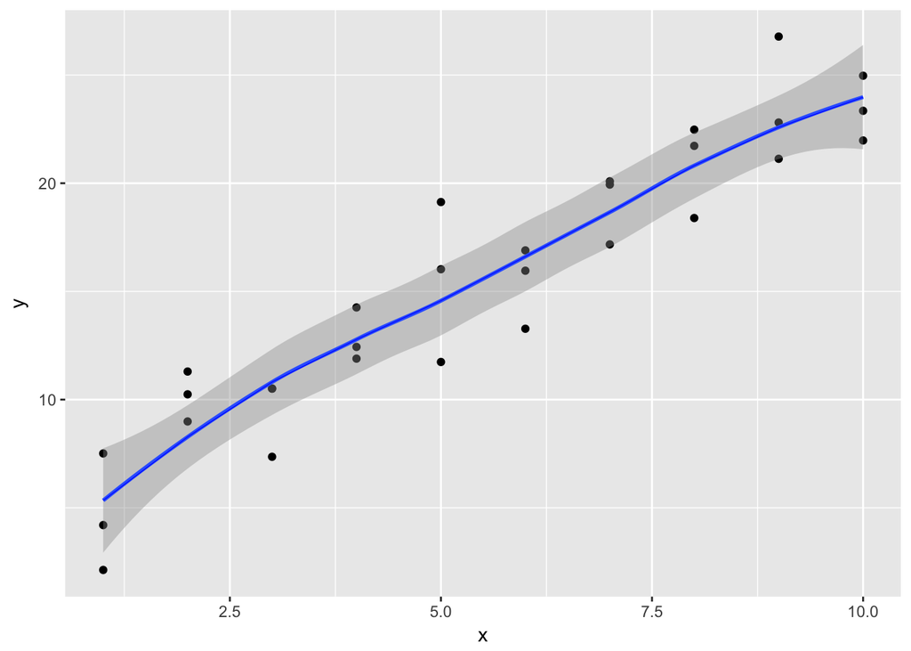

```
Even the message tells us that `geom_smooth()` using method = 'loess'
```

```r
sim1_mod_loess <- loess(y ~ x, data=sim1)
grid <- sim1 %>% data_grid(x) %>% add_predictions(sim1_mod_loess)

ggplot(sim1, aes(x = x)) + geom_point(aes(y = y)) + geom_smooth(aes(y = y)) + geom_line(aes(y = pred), data = grid, colour = "blue", size = .2)
```

# 3

What does geom_ref_line() do? What package does it come from? Why is displaying a reference line in plots showing residuals useful and important?

```
"geom_ref_line()" adds a reference line to a plot(ggplot2). It is from package(modelr). It helps us visualize the pattern around the reference line.
```

23.4.5 #2 Use model_matrix() to explore the equations generated for the models I fit to sim3 and sim4. Why is * a good shorthand for interaction? (only the part for sim3)

```r
mod_int <- lm(y~x1*x2, data = sim3)
summary(mod_int)
```

```
##
## Call:
## lm(formula = y ~ x1 * x2, data = sim3)
##
## Residuals:
##      Min       1Q   Median       3Q      Max
## -2.87634 -0.67655  0.04837  0.69963  2.58607
##
## Coefficients:
##             Estimate Std. Error t value Pr(>|t|)
## (Intercept)  1.30124    0.40400   3.221  0.00167 **
## x1          -0.09302    0.06511  -1.429  0.15587
## x2b          7.06938    0.57134  12.373  < 2e-16 ***
## x2c          4.43090    0.57134   7.755 4.41e-12 ***
## x2d          0.83455    0.57134   1.461  0.14690
## x1:x2b      -0.76029    0.09208  -8.257 3.30e-13 ***
## x1:x2c       0.06815    0.09208   0.740  0.46076
## x1:x2d       0.27728    0.09208   3.011  0.00322 **
## ---
## Signif. codes:  0 '***' 0.001 '**' 0.01 '*' 0.05 '.' 0.1 ' ' 1
##
## Residual standard error: 1.024 on 112 degrees of freedom
## Multiple R-squared:  0.8221, Adjusted R-squared:  0.811
## F-statistic: 73.93 on 7 and 112 DF,  p-value: < 2.2e-16
```

```r
mod_line<- lm(y~x1 + x2, data = sim3)
summary(mod_line)
```

```
##
## Call:
## lm(formula = y ~ x1 + x2, data = sim3)
##
## Residuals:
##     Min      1Q  Median      3Q     Max
## -4.4674 -0.8524 -0.0729  0.7886  4.3005
##
## Coefficients:
##             Estimate Std. Error t value Pr(>|t|)
## (Intercept)  1.87167    0.38738   4.832 4.22e-06 ***
## x1          -0.19674    0.04871  -4.039 9.72e-05 ***
## x2b          2.88781    0.39571   7.298 4.07e-11 ***
## x2c          4.80574    0.39571  12.145  < 2e-16 ***
## x2d          2.35959    0.39571   5.963 2.79e-08 ***
## ---
## Signif. codes:  0 '***' 0.001 '**' 0.01 '*' 0.05 '.' 0.1 ' ' 1
##
## Residual standard error: 1.533 on 115 degrees of freedom
## Multiple R-squared:  0.5911, Adjusted R-squared:  0.5768
## F-statistic: 41.55 on 4 and 115 DF,  p-value: < 2.2e-16
```

```r
model_matrix(sim3, mod_int)
```

```
## # A tibble: 120 x 8
##    `(Intercept)`    x1   x2b   x2c   x2d `x1:x2b` `x1:x2c` `x1:x2d`
##            <dbl> <dbl> <dbl> <dbl> <dbl>    <dbl>    <dbl>    <dbl>
##  1             1     1     0     0     0        0        0        0
##  2             1     1     0     0     0        0        0        0
##  3             1     1     0     0     0        0        0        0
##  4             1     1     1     0     0        1        0        0
##  5             1     1     1     0     0        1        0        0
##  6             1     1     1     0     0        1        0        0
##  7             1     1     0     1     0        0        1        0
##  8             1     1     0     1     0        0        1        0
##  9             1     1     0     1     0        0        1        0
## 10             1     1     0     0     1        0        0        1
## # ... with 110 more rows
```

```r
model_matrix(sim3, mod_line)
```

```
## # A tibble: 120 x 5
##    `(Intercept)`    x1   x2b   x2c   x2d
##            <dbl> <dbl> <dbl> <dbl> <dbl>
##  1             1     1     0     0     0
##  2             1     1     0     0     0
##  3             1     1     0     0     0
##  4             1     1     1     0     0
##  5             1     1     1     0     0
##  6             1     1     1     0     0
##  7             1     1     0     1     0
##  8             1     1     0     1     0
##  9             1     1     0     1     0
## 10             1     1     0     0     1
## # ... with 110 more rows
```

```
* is good for interaction because the model that uses * has a different slope and intercept for each line, which can plot the regression lines for each X2 categories.
```

# 3

Using the basic principles, convert the formulas in the following two models into functions. (Hint: start by converting the categorical variable into 0-1 variables.)

```r
mod1 <- lm(y ~ x1 + x2, data = sim3)

mod_1 <-function(data){
matrix_x=as.matrix(model_matrix(y~x1+x2, data=sim3))
matrix_Y=matrix(sim3$y, ncol=1)
beta=solve(t(matrix_x) %*% matrix_x) %*% t(matrix_x) %*% matrix_Y
return(beta)
}

mod_1(sim3)
```

```
##                   [,1]
## (Intercept)  1.8716659
## x1          -0.1967378
## x2b          2.8878108
## x2c          4.8057359
## x2d          2.3595867
```

```r
mod2 <- lm(y ~ x1 * x2, data = sim3)
mod_2<-function(data){
matrix_x=as.matrix(model_matrix(y~x1*x2, data=sim3))
matrix_Y=matrix(sim3$y, ncol=1)
beta=solve(t(matrix_x) %*% matrix_x) %*% t(matrix_x) %*% matrix_Y
return(beta)
}

mod_2(sim3)
```

```
##                    [,1]
## (Intercept)  1.30124266
## x1          -0.09302444
## x2b          7.06937991
## x2c          4.43089525
## x2d          0.83455115
## x1:x2b      -0.76028528
## x1:x2c       0.06815284
## x1:x2d       0.27727920
```

3.5.1 #2 What do the empty cells in plot with facet_grid(drv ~ cyl) mean? How do they relate to this plot?

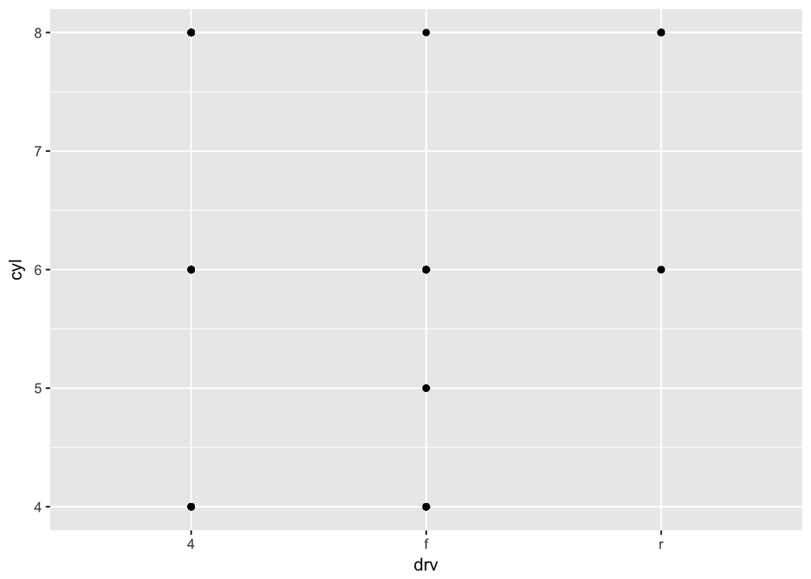

```r
ggplot(data = mpg) + geom_point(mapping = aes(x = drv, y = cyl))
```

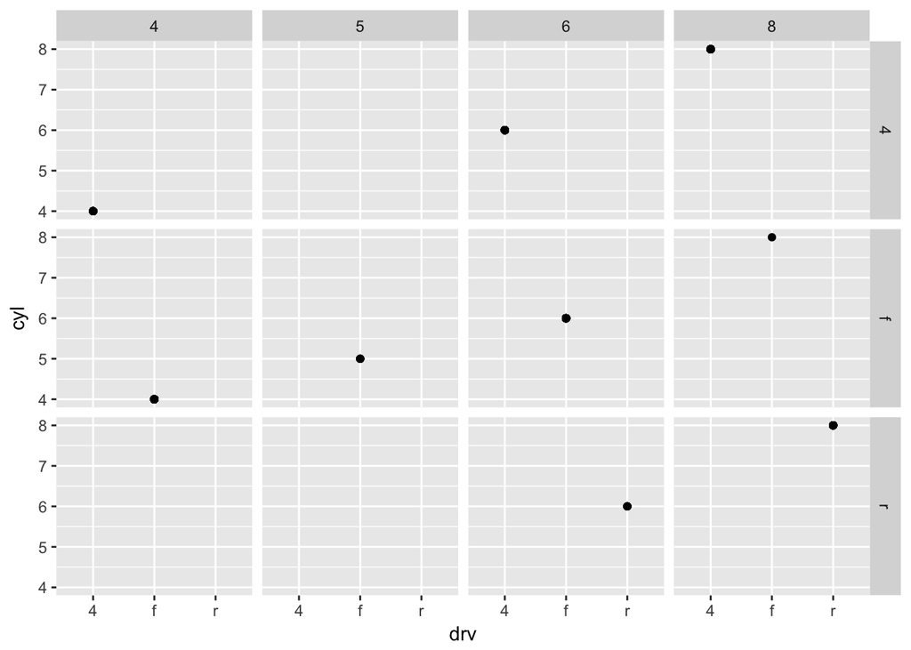

```
Empty cells in facet_grid imply that there were no rows with that combination of values in the original dataset. In this plot we can see that there are no vehicles with 5 cylinders with 4 wheel drive.
```

```r
ggplot(data = mpg) + geom_point(mapping = aes(x = drv, y = cyl)) + facet_grid(drv ~ cyl)
```

# 3

What plots does the following code make? What does . do?

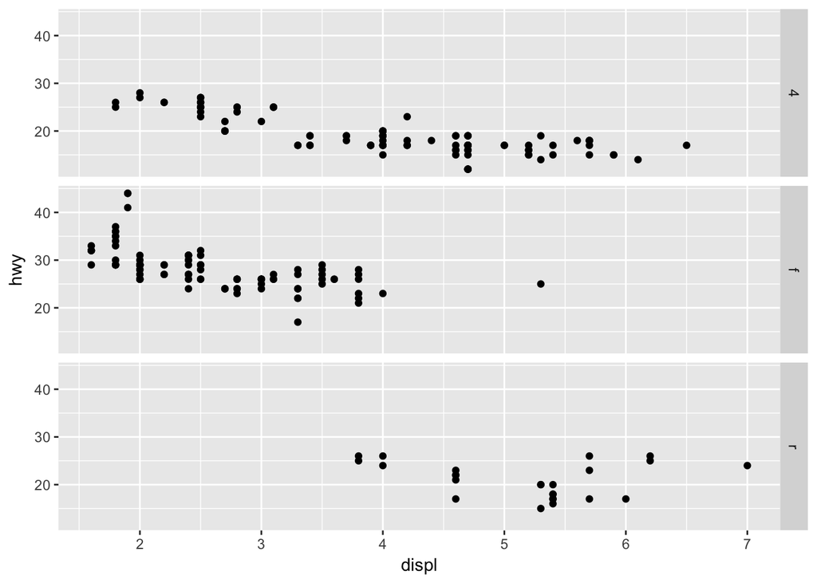

```r
ggplot(data = mpg) +
  geom_point(mapping = aes(x = displ, y = hwy)) +
  facet_grid(drv ~ .)
```

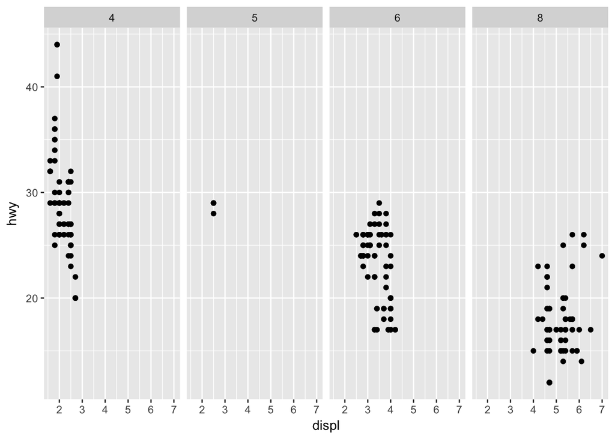

```
. is a placeholder which help us to have a facet in only one dimension. In facet_grid(), this results in a plot faceted on a single dimension (1 by N or N by 1) rather than an N by N grid. This is necessary because one sided formulae may cause problems.
```

```r
ggplot(data = mpg) +
  geom_point(mapping = aes(x = displ, y = hwy)) +
  facet_grid(. ~ cyl)
```

# 6

When using facet_grid() you should usually put the variable with more unique levels in the columns. Why?

```
Most screens are wider than they are tall. Thus, when making the plot vertically, we need more unique levels in the columns. When making it horizontally, the plot will be compressed and harder to view.
```